# Where and When Pulang Pisau Burned

Where fires burned, when, and whether one fire leads to the next

ZeXin Chen

27 September 2026

## Contents

**Part 1, The Problem and the Data**

- Why Pulang Pisau
- Cleaning the raw satellite data
- Six questions, each checked against chance

**Part 2, First-Order Analysis**

- Insight 1, when the fires came
- Insight 2, where they burned

**Part 3, Second-Order Analysis**

- Insight 3, how clustered fires are
- Insight 4, nearby fires follow each other

**Part 4, Bonus**

- Insight 5, a daily watch zone for patrols

**Part 5, So What**

- Key findings and their limits
- Public-safety implications

## Pulang Pisau had the densest fire detections of any Kalimantan regency

Part 1 · The problem and the data

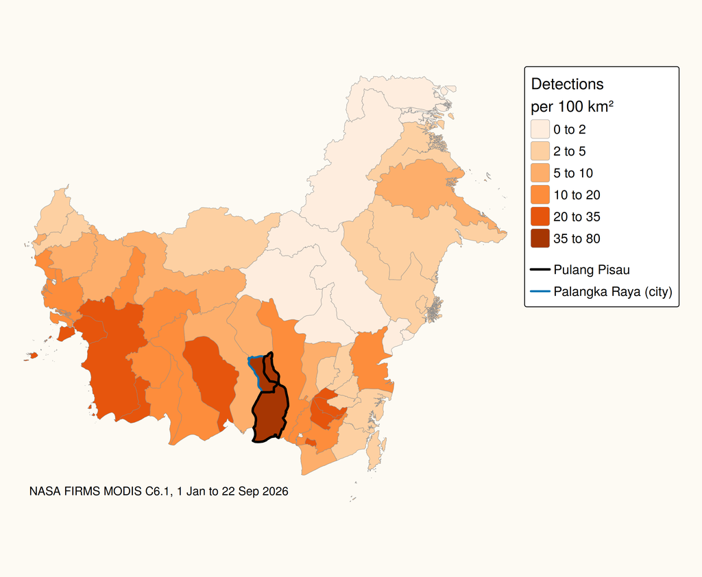

The 2026 season

3,693.7 ha

burned in 8 subdistricts by 17 Sep

595 µg/m³

PM2.5 on 17 Sep, about 40 times the WHO 24-hour guideline (Berita Sampit, 2026; WHO, 2021)

The regent raised the fire status to emergency response. Most of the regency is deep peat inside the failed Mega Rice Project, drained by canals in the 1990s.

**Research question.** Where and when did fires burn in 2026, and were fires closer together in space and time than uneven fuel alone would explain?

## Three fixes turned 50,877 raw detections into 3,065 fire-days

Part 1 · The problem and the data

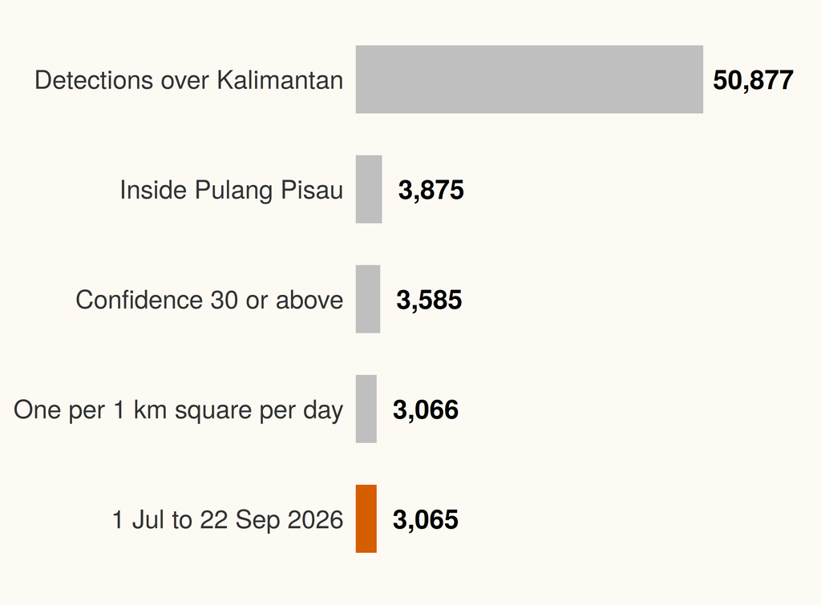

**Wrong day.** Satellite times are in UTC. 6,026 night detections were moved to the right local day.

**Counted up to four times.** Four passes a day can see the same fire, so repeats were merged to one event per 1 km square per day.

**False alarms.** Detections with confidence under 30 were dropped.

A **fire-day** is one 1 km square burning on one local day. MODIS is the main sensor, and VIIRS is rerun as a check.

## Six questions, each checked against what chance would give

Part 1 · The problem and the data

|  | Question | Method | Compared with |
| --- | --- | --- | --- |
| **Q1** | When and where did fires burn? | Kernel density, in space and in space-time | Nothing, it maps where fires were dense |
| **Q2** | Are fires closer together than random? | L function | Fires placed at random |
| **Q3** | Still closer once busy areas are allowed for? | Inhomogeneous L function | Random, but following the density map |
| **Q4** | Do nearby fires also burn close in time? | Knox test | Same places, dates shuffled within 10 km blocks |
| **Q5** | Do roads and canals explain it? *(bonus)* | Point process model | Random, but more fires near roads and canals |
| **Q6** | Do recent fires point to new ones? *(bonus)* | Daily back-test | A hotspot map of the same size |

## Insight 1. Fire came late and fast, 82% of fire-days fell in September

Part 2 · First-order analysis

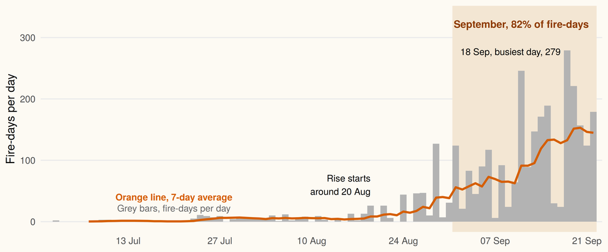

The one-day dips, such as 16 and 17 Sep, are most likely cloud or smoke hiding fires. 46% of fire-days were a 1 km square burning again within a week, most often the next day, so crews should go back to fires that look out.

## Insight 2. Fire spread from the neck to the southern peat

Part 2 · First-order analysis

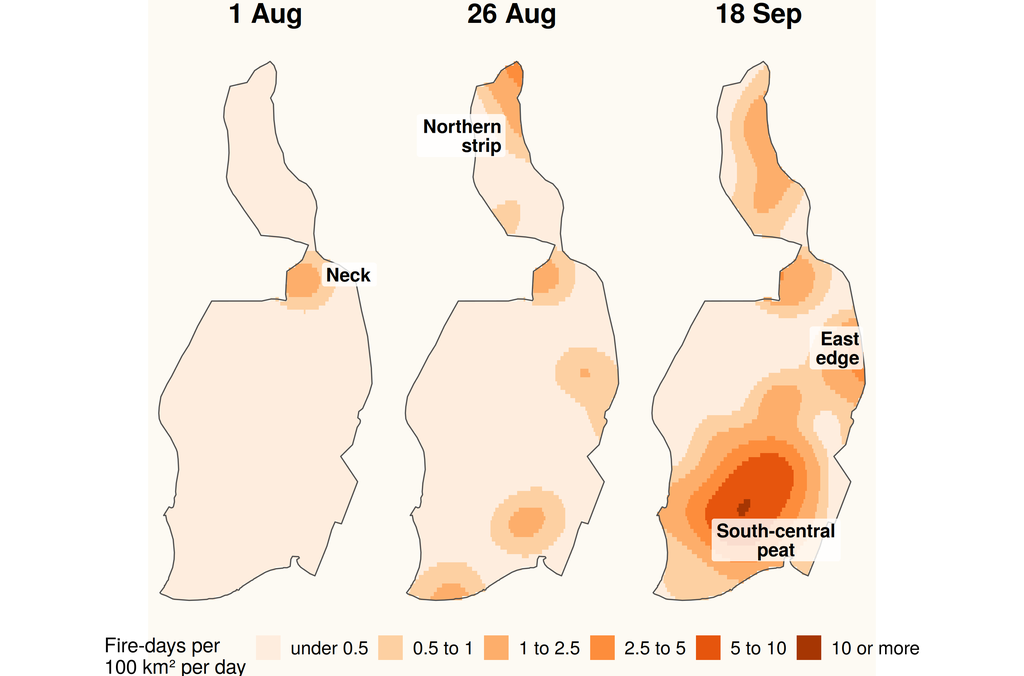

**July.** Almost all burning was just below the narrow neck.

**Late August.** New fires started in the north, on the east edge and on the south coast.

**September.** The south-central peat burned hardest, with a second hot spot on the east edge.

Spatio-temporal kernel density. The same peak appears with 2 km, 7.5 km and adaptive bandwidths in the report.

## Insight 3. Fires cluster far more than chance, but a map cannot say why

Part 3 · Second-order analysis

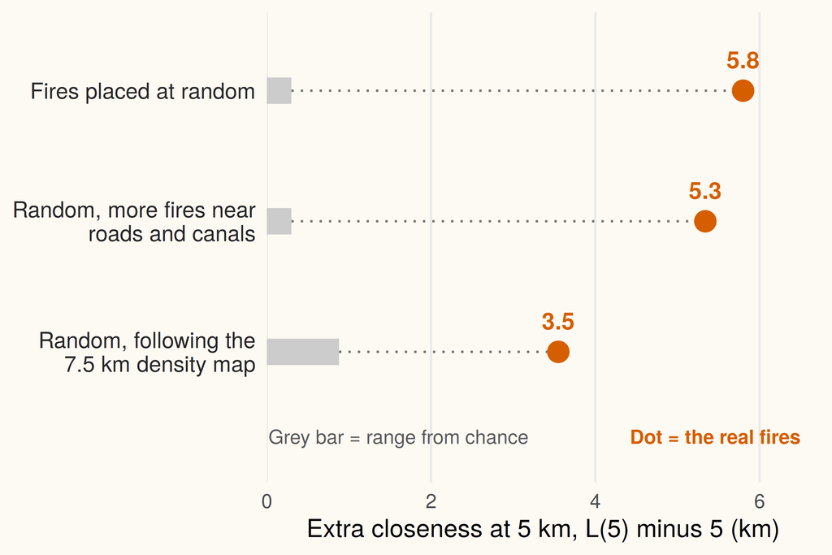

**Far from random.** The nearest fire is about half as far away as chance would put it (Clark-Evans ratio 0.48).

**Roads and canals barely help.** Allowing for access closes little of the gap.

**The density map decides.** With a 5 km map instead of 7.5 km, the gap disappears. One map cannot tell fires affecting each other from land that simply burns easily, so time is needed.

## Insight 4. Fires under 3 km apart follow each other within 1 to 3 days

Part 3 · Second-order analysis

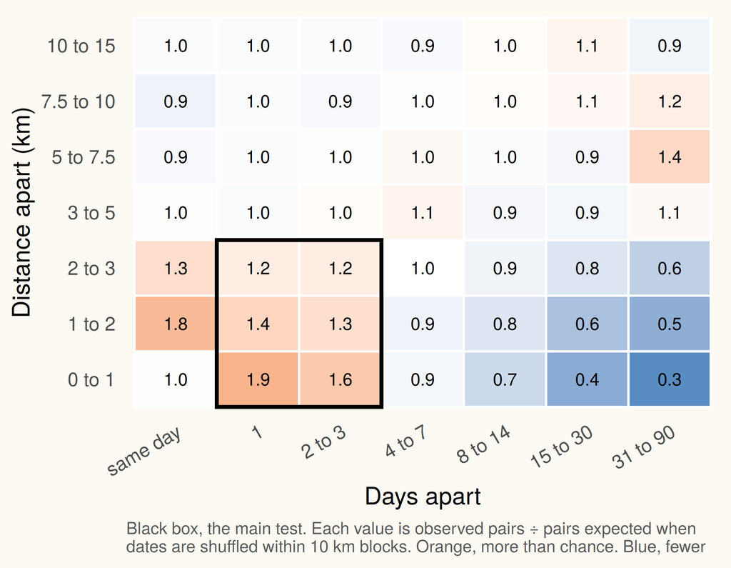

1.33×

as many close pairs as chance, p = 0.005, even with each 10 km block keeping its own fire season

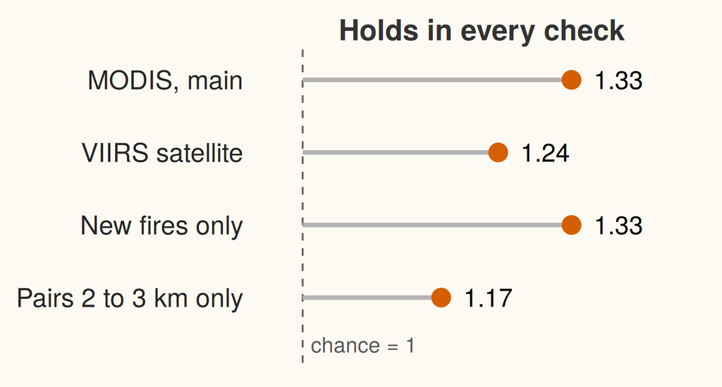

## Insight 5. Watching near recent fires beat a hotspot map

Part 4 · Bonus

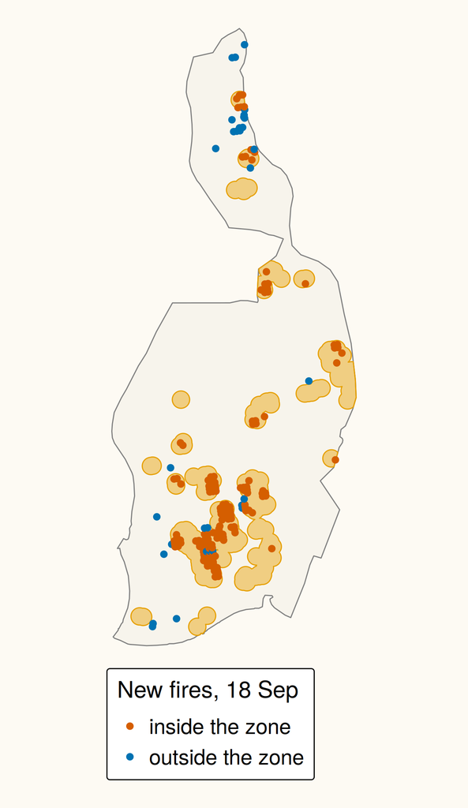

76%

of new fires caught by the watch zone

64%

by the best hotspot map of the same size

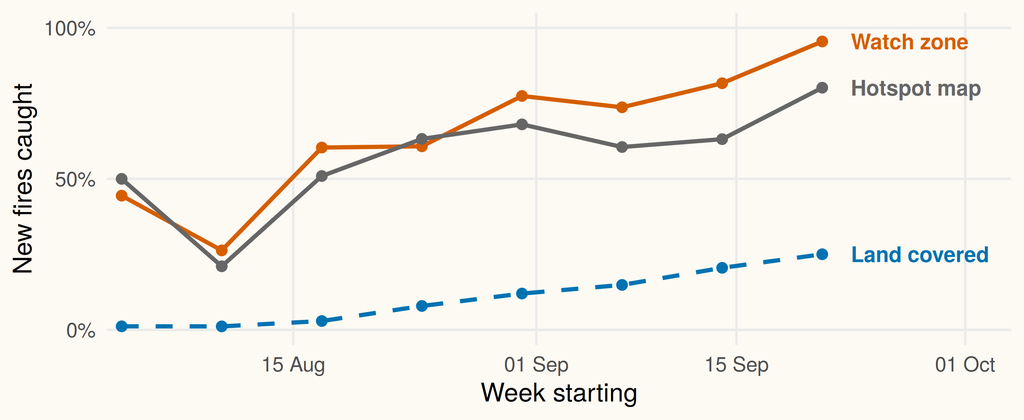

Watch zone, the land within 3 km of the last three days’ fires. Hotspot map, the same amount of land where the most fires had burned so far.

## Key findings and their limits

Part 5 · So what

|  | Finding | Evidence | Main limit |
| --- | --- | --- | --- |
| **1** | The season came late and fast | 82% of fire-days fell in September | Cloud and smoke hide fires at the peak, and data after 30 June is provisional |
| **2** | The south-central peat burned most | Same peak at 2 km, 7.5 km and adaptive bandwidths | Counts fire-days, not burned area or harm |
| **3** | Fires cluster far beyond random | L function far above the envelope, Clark-Evans ratio 0.48 | After allowing for density, the result changes with bandwidth, so Q3 stays open |
| **4** | Fires close in space are close in time | Pairs under 3 km and 1 to 3 days apart 1.33 times as common as chance, also for VIIRS | Cannot tell spread from one person lighting several plots |
| **5** | Recent fires find new fires better than a hotspot map | Watch zone 76% against at most 64% on the same area | One season, and the 3 km and 3 days came from the same data |
| **6** | Roads and canals explain little of the clustering | Only 4 of 3,065 fire-days over 14 km from a road, but the access model barely lowers L | OSM misses many canals |

**Core finding.** Density maps show where to base crews. The space-time result, and the watch zone built on it, show where to look each day.

## What this means for fire management in Pulang Pisau

Part 5 · So what

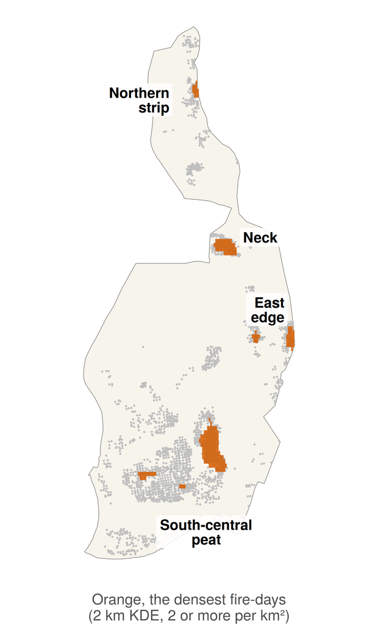

**Base crews and water in the south-central peat and east edge**  
Because both had the densest burning at every bandwidth, and water shortages already slow firefighting  
Check first burned area and peat depth

**Draw a 3 km watch zone each morning and patrol it first**  
Because it caught 76% of new fires, against 64% for a hotspot map of the same size  
Check first a test on another fire season

**Go back to put-out fires the next day**  
Because 46% of fire-days were a square burning again within a week  
Check first field records of fires that restarted

**Watch the neck early in the season**  
Because it burned from July, weeks before the rest of the regency  
Check first earlier years and rainfall data

Each action rests on evidence from this study but needs the check first. Nothing here shows cause. The watch zone says where the next fire is likely, not whether it spread or was lit.

## References

- Baddeley, A., Rubak, E. and Turner, R. (2015). *Spatial Point Patterns: Methodology and Applications with R*. Chapman and Hall/CRC.
- Berita Sampit (2026, 18 September). Karhutla Pulpis capai 3.693 hektare, kualitas udara berada pada level berbahaya.
- Davies, T. M., Marshall, J. C. and Hazelton, M. L. (2018). Tutorial on kernel estimation of continuous spatial and spatiotemporal relative risk. *Statistics in Medicine*, 37(7), 1191 to 1221.
- Diggle, P. J. (2013). *Statistical Analysis of Spatial and Spatio-Temporal Point Patterns* (3rd ed.). CRC Press.
- Giglio, L., Schroeder, W. and Justice, C. O. (2016). The collection 6 MODIS active fire detection algorithm and fire products. *Remote Sensing of Environment*, 178, 31 to 41.
- Knox, E. G. (1964). The detection of space-time interactions. *Journal of the Royal Statistical Society, Series C*, 13(1), 25 to 30.
- Page, S. E. and Hooijer, A. (2016). In the line of fire, the peatlands of Southeast Asia. *Philosophical Transactions of the Royal Society B*, 371, 20150176.
- Townsley, M., Homel, R. and Chaseling, J. (2003). Infectious burglaries, a test of the near repeat hypothesis. *British Journal of Criminology*, 43(3), 615 to 633.
- WHO (2021). *WHO Global Air Quality Guidelines*. World Health Organization, Geneva.

Data from NASA FIRMS, GADM 4.1 and OpenStreetMap. Full list, code and workflow in the Technical Report.